# Coursework Report

*N* removed NAs: 3

*N* removed typo: 1

*N* removed <18: 22

*N* total clean: 124

| Group | *N* | *M*<sub>age</sub> | *M*<sub>rating</sub> |
| --- | --- | --- | --- |
| Control | 67 | 20.67 | 6.81 |
| Experim | 57 | 20.93 | 5.73 |

**Main analysis results**

*t*(122) = 8.12, *p* < .001

[interactive chart not shown]

[figure not shown]

[interactive chart not shown]

# Coursework Report

Analysing Data, Spring 2020

# Methods

## Participants

Figure 1 *Descriptive Statistics By Group*

| Group | *N* | % | *M*<sub>age</sub> | *SD*<sub>age</sub> | *MIN*<sub>age</sub> | *MAX*<sub>age</sub> |
| --- | --- | --- | --- | --- | --- | --- |
| control | 77 | 52.74 | 19.84 | 3.15 | 6 | 25 |
| experimental | 69 | 47.26 | 20.17 | 2.37 | 15 | 26 |

## Design

The question under examination is whether the perception of attractiveness in females is influenced by the colour red. Attractiveness perception was measured using a 9-point scale, where by 1 was considered the lowest rating, referring to ‘not at all attractive’ and 9 being the highest rating labelled as ‘extremely attractive’. The attractiveness variable was measured using this scale on three items, after which an average of the scores was made, creating a composite index. The group variable is a factor with 2 levels: “experimental” and “control”. The experimental condition involved participants viewing a black and white image (4" x 6“) of a brown haired, Caucasian male of average attractiveness, with a red frame (8.5” x 11"). Whereas, the control condition had participants view the same image on a white frame. The null hypothesis states: there will be no difference in the means of attractiveness rating for participants in the control condition compared to those in the experimental condition (H<sub>0</sub>: μAR_control = μAR_experimental), whereas, the alternative hypothesis states that there will be a significant difference in these means (H<sub>1</sub> : μAR_control <> μAR_experimental). An independent samples t-test will be used in order to statistically analyse and test the operational hypothesis: Does the colour of the frame surrounding an image of a moderately attractive man influence females perception of his mean attractiveness on a 9-point scale?

# Results

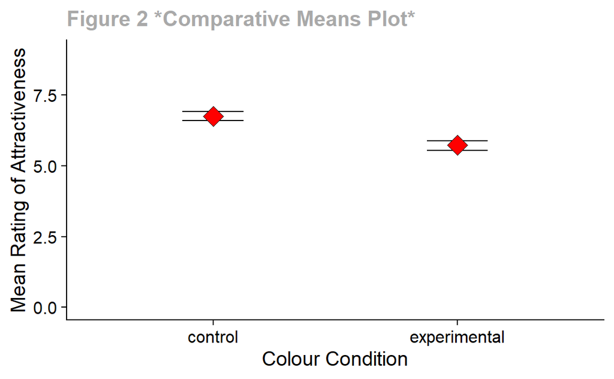

# Discussion

The results of this study have found the null hypothesis to be extremely unlikely and in need of rejection. The alternative hypothesis in this case is accepted, suggesting that there is in fact a relationship between colour and a women’s perception of attractiveness in such a way that the colour red negatively influences this perception when in comparison to white. These finding, however, contradict those found in the original study by Elliot et al, whose participants rated the red framed man as more attractive than the white framed man (Elliot et al, 2010). Due to the lack of similarities in the patten of our findings and those in the original study, it could perhaps infer that there are more variables involved in attraction than were previously recognised. For example, the individual preferences of the participants, the length of time in which they were exposed to the image, the participants age, or their culture. There are many studies that support Elliot et al’s results, such as the study completed by Young who found red enhanced men’s rating of female attractiveness (Young, 2015). However, there are alternate studies that, like our study prior, fail to support this “red effect”. An example of one of these studies being by Leonard et al, who presented three empirical studies investigating the effects of temporal context and culture on the “red effect”, all of which failed to support this ideology that red influences attraction (Peperkoorn, Roberts & Pollet, 2016). With reference to our findings, it is clear to see they oppose those of many studies that have taken place, due to highlighting a negative relationship between red and attractiveness ratings. Yet, in terms of investigating the “red effect”, they help expose more options for explanation with there already being a considerable amount of contradicting evidence surrounding this subject. The plethora of findings available on this topic could be due to methodological issues in replicating similar environments, for example differences in colour stimuli or perhaps alternatively, due to various other factors that have been found to influence the “red effect”. For instance, variables for men can include whether the woman has a masculine face (Wen et al, 2014) or whether they are postmenopausal (Schwarz & Singer, 2013).

A meta- analysis by Lehmann, Elliot and Callin-Jageman of studies involving the red-romance hypothesis has found that, for a between- subjects design, such as the one used in our study, 930 participants per condition is needed for more accurate findings as indicated by the size effect estimates, which their meta-analysis discovered (Lehmann, Elliot & Callin-Jageman, 2018). This highlights a limitation to our investigation, suggesting that our sample size was in fact too small to be representative of the population and could increase the likelihood of the results being a product if a Type II error. This would skew our results, leading them to become inaccurate, decreasing the overall power of the study. Alternatively, the between-groups design leads to a reduction in demand characteristic, meaning the ratings are going to be more consistent with the participants true feelings. Additionally, although the self-report data involved in the attractiveness rating scale is an inexpensive tool that produces data that can be easily analysed, the self-report aspect can create issues with validity. For example, the interpretations of the 3 items may differ among participants or the rating itself can be subject to each participants inclination to give high, low, or middle responses.

With the limitations of our study and the consistent contradiction from many alternative studies, it may be suggested that the results found may have inaccuracies and therefore, the null hypothesis may indeed be true. Nevertheless, I believe this has given insight into the complex nature of colour-in-context theories and the relationship between red and attraction. With this in consideration, I do believe there should be further research investigating this subject area due to its intricacy. This research could involve looking at forced-choice paradigms that could be used to reduce participant variables found using a rating scale (pazda, Thorstenson & Elliot, 2018) and ceiling effects could be considered prior to the study taking place because if the stimuli is considered very attractive it may interfere with the dependent variable under investigation. Finally, I feel an important way of understanding the concept of the “red effect” would be to increase the amount of publicly preregistered reports in this research area in order to reduce any data dredging that could take place and help prevent the bias in publication toward only significant results, as it may be insignificant results that lead to a more successful understanding of this topic.

To conclude, the analysis of our results has shown the null hypothesis to be extremely unlikely, therefore suggesting that, contradictive to Elliot et al’s original findings, red has a negative impact on female attractive perception of men. However, methodological issues have reduced the validity of our results leadings to questions in their significance. Although there are differences in the interpretations of our findings, the results can still offer important data for subsequent research into the “red effect”.

# References

- Elliot, A. J., Kayser, D. N., Greitemeyer, T., Lichtenfeld, S., Gramzow, R. H., Maier, M. A.…Liu, H. (2010). Red, rank, and romance in women viewing men. Journal of Experimental Psychology: General, 139(3), 399–417. doi:10.1037/a0019689
- Young, S. G. (2015). The effect of red on male perceptions of female attractiveness: Moderation by baseline attractiveness of female faces. European Journal of Social Psychology, 45(2), 146–151. doi:10.1002/ejsp.2098
- Peperkoorn, L. S., Roberts, S. C., Pollet, T. V. (2016). Revisiting the Red Effect on Attractiveness and Sexual Receptivity: No Effect of the Color Red on Human Mate Preferences. Evolutionary Psychology. 14(4), 1-13. Doi:10.1177/1474704916673841
- Lehmann, G. K., Elliot, A. J., Calin-Jageman, R. J. (2018). Meta-Analysis of the Effect of Red on Perceived Attractiveness. Evolutionary Psychology, 16(4), 1-27.
- Wen, F., Zuo, B., Wu, Y., Sun, S., & Liu, K. (2014). Red is romantic, but only for feminine females: Sexual dimorphism moderates red effect on sexual attraction. Evolutionary Psychology, 12(4), 719–735. Doi:10.1177/147470491401200404
- Schwarz, S., & Singer, M. (2013). Romantic red revisited: Red enhances men’s attraction to young, but not menopausal women. Journal of Experimental Social Psychology, 49(1), 161–164. Doi:10.1016/j.jesp.2012.08.004 doi:10.1177/1474704918802412
- Pazda, A. D., Thorstenson, C. A., Elliot, A. J. (2016). Unpublished data. Retrieved from https://osf.io/dgjx2/